# Practical AI for Medical Data — a reproducible model report

Predicting in-hospital death after a heart-failure episode

Published

June 4, 2026

## What this report does

This is the reproducible deliverable of the workshop. It **runs the entire analysis as it renders** — split → preprocess → tune four model families on cross-validation → finalize the winner → validate once on the held-out test set — and then reports the result. Nothing is typed in by hand and nothing is reloaded from a private cache: **every number and figure below was produced by the same render that prints it.** Re-render on any machine with the pinned environment and you reproduce the *analysis*, not just the document.

```r
library(here)
library(rio)
library(tidyverse)
library(janitor)
library(tidymodels)
library(gtsummary)
```

## The cohort

```r
# Load & wrangle exactly as in Steps 00-01 ----
hf <- import(here("data-raw", "heart_failure.csv"), setclass = "tibble") |>
  clean_names() |>
  select(-time) |>
  mutate(
    outcome = factor(
      if_else(death_event == 1, "died", "survived"),
      levels = c("died", "survived"),
    ),
  ) |>
  select(-death_event) |>
  mutate(across(c(anaemia, diabetes, high_blood_pressure, sex, smoking), factor))
```

The analysis cohort is the heart-failure clinical records (Chicco & Jurman 2020): 299 patients, of whom 32.1% died during follow-up. The table below summarises the eleven candidate predictors, stratified by outcome.

```r
hf |>
  tbl_summary(
    by = outcome,
    include = c(
      age, sex, ejection_fraction, serum_creatinine, serum_sodium,
      creatinine_phosphokinase, platelets, anaemia, diabetes,
      high_blood_pressure, smoking,
    ),
  )
```

| **Characteristic** | **died** N = 96<sup>1</sup> | **survived** N = 203<sup>1</sup> |
| --- | --- | --- |
| age | 65 (55, 75) | 60 (50, 65) |
| sex |  |  |
| 0 | 34 (35%) | 71 (35%) |
| 1 | 62 (65%) | 132 (65%) |
| ejection_fraction | 30 (25, 38) | 38 (35, 45) |
| serum_creatinine | 1.30 (1.05, 1.90) | 1.00 (0.90, 1.20) |
| serum_sodium | 136 (133, 139) | 137 (135, 140) |
| creatinine_phosphokinase | 259 (129, 582) | 245 (109, 582) |
| platelets | 258,500 (197,000, 312,000) | 263,000 (219,000, 302,000) |
| anaemia |  |  |
| 0 | 50 (52%) | 120 (59%) |
| 1 | 46 (48%) | 83 (41%) |
| diabetes |  |  |
| 0 | 56 (58%) | 118 (58%) |
| 1 | 40 (42%) | 85 (42%) |
| high_blood_pressure |  |  |
| 0 | 57 (59%) | 137 (67%) |
| 1 | 39 (41%) | 66 (33%) |
| smoking |  |  |
| 0 | 66 (69%) | 137 (67%) |
| 1 | 30 (31%) | 66 (33%) |

<sup>1</sup> Median (Q1, Q3); n (%)

## Split and preprocess

We hold out a stratified 25% test set that **no tuning ever sees**, and build the same recipe used throughout the workshop (dummy-code, drop zero-variance, normalize — no imputation, the data has no missing values).

```r
# Split: a held-out test set the tuning never touches ----
set.seed(123)
data_split <- initial_split(hf, prop = 0.75, strata = outcome)
train <- training(data_split)
test  <- testing(data_split)

# Recipe ----
base_rec <- recipe(outcome ~ ., data = train) |>
  step_dummy(all_nominal_predictors()) |>
  step_zv(all_predictors()) |>
  step_normalize(all_numeric_predictors())
```

## Tune four model families on cross-validation

Each spec leaves its hyperparameters as `tune()`. We bundle the one recipe with the four specs into a `workflow_set`, then tune every workflow over a shared 5-fold cross-validation, scoring **both** AUC-ROC and AUC-PR.

```r
# Model specs (hyperparameters left to tune) ----
penlog_spec <- logistic_reg(penalty = tune(), mixture = tune()) |> set_engine("glmnet")
knn_spec    <- nearest_neighbor(neighbors = tune()) |> set_engine("kknn")   |> set_mode("classification")
svm_spec    <- svm_rbf(cost = tune(), rbf_sigma = tune()) |> set_engine("kernlab") |> set_mode("classification")
rf_spec     <- rand_forest(mtry = tune(), min_n = tune()) |> set_engine("ranger")  |> set_mode("classification")

# One shared resampling scheme and metric set ----
folds      <- vfold_cv(train, v = 5, strata = outcome)
hf_metrics <- metric_set(roc_auc, pr_auc)

# Bundle {one recipe} x {four specs}, then tune every workflow ----
wf_set <- workflow_set(
  preproc = list(rec = base_rec),
  models  = list(penlog = penlog_spec, knn = knn_spec, svm = svm_spec, rf = rf_spec),
)

wf_res <- wf_set |>
  workflow_map(
    "tune_grid",
    resamples = folds,
    grid      = 8,
    metrics   = hf_metrics,
    seed      = 123,
    verbose   = FALSE,
  )
```

[output not shown]

The ranking by cross-validated AUC-ROC (the honest comparison — it never touches the test set):

```r
wf_rank <- rank_results(wf_res, rank_metric = "roc_auc", select_best = TRUE)

model_label <- c(
  rec_penlog = "Penalized logistic (glmnet)",
  rec_knn    = "k-nearest neighbours",
  rec_svm    = "RBF support vector machine",
  rec_rf     = "Random forest"
)

wf_rank |>
  dplyr::filter(.metric == "roc_auc") |>
  transmute(
    Model        = model_label[wflow_id],
    `CV AUC-ROC` = round(mean, 3),
    `Std. error` = round(std_err, 3),
    Rank         = rank,
  )
```

```
# A tibble: 4 × 4
  Model                       `CV AUC-ROC` `Std. error`  Rank
  <chr>                              <dbl>        <dbl> <int>
1 Random forest                      0.781        0.025     1
2 Penalized logistic (glmnet)        0.728        0.022     2
3 RBF support vector machine         0.708        0.021     3
4 k-nearest neighbours               0.639        0.026     4
```

## Finalize the winner and validate once

We take the top-ranked workflow, lock in its best hyperparameters, refit on the full training set, and score it **once** on the untouched test set.

```r
best_id     <- wf_rank |>
  dplyr::filter(.metric == "roc_auc") |>
  dplyr::slice_min(rank, n = 1) |> dplyr::pull(wflow_id)
best_res    <- extract_workflow_set_result(wf_res, best_id)
best_params <- select_best(best_res, metric = "roc_auc")
final_wf    <- wf_set |> extract_workflow(best_id) |> finalize_workflow(best_params)

final_fit <- last_fit(
  final_wf,
  split   = data_split,
  metrics = metric_set(roc_auc, pr_auc, accuracy),
)

cv_auc       <- wf_rank |>
  dplyr::filter(.metric == "roc_auc") |>
  dplyr::slice_min(rank, n = 1) |> dplyr::pull(mean)
test_metrics <- collect_metrics(final_fit)
get_metric   <- function(m) {
  test_metrics |> dplyr::filter(.metric == m) |> dplyr::pull(.estimate)
}
test_roc <- get_metric("roc_auc")
test_pr  <- get_metric("pr_auc")
test_acc <- get_metric("accuracy")
```

The winner is **Random forest**. Its cross-validated AUC-ROC was **0.781**; refit on the training split and scored once on the held-out test set, it reached a test AUC-ROC of **0.869**, an AUC-PR of **0.735**, and an accuracy of **0.8**. The gap between the cross-validated and the single-split test numbers is the honest noise of a small cohort (~75 test patients) — which is exactly why we pre-commit to one held-out evaluation and read it *alongside* the cross-validation, never a single number on its own.

## Test-set ROC and PR curves

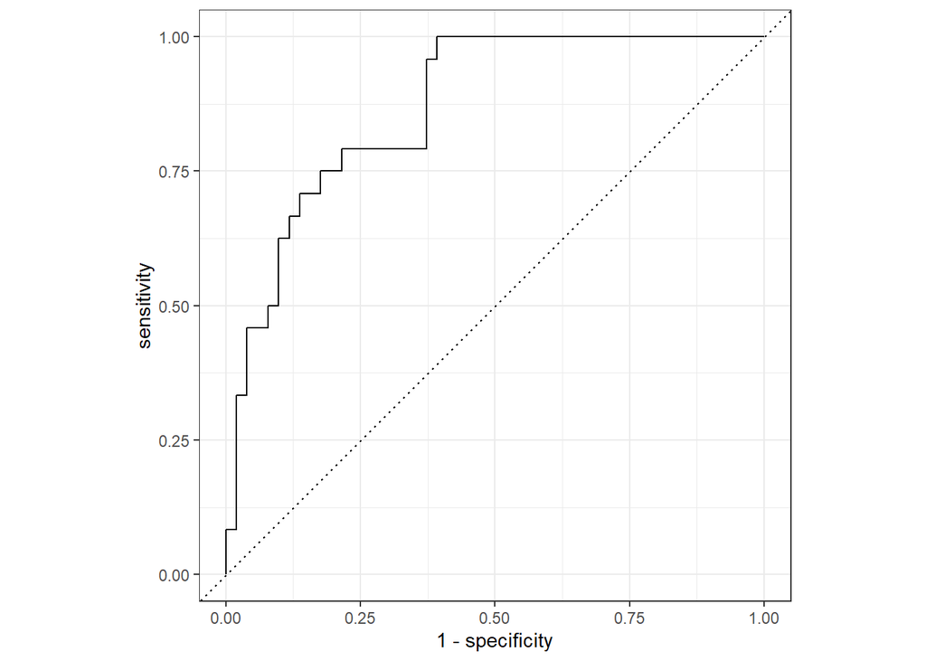

```r
preds <- collect_predictions(final_fit)

preds |> roc_curve(outcome, .pred_died) |> autoplot()
```

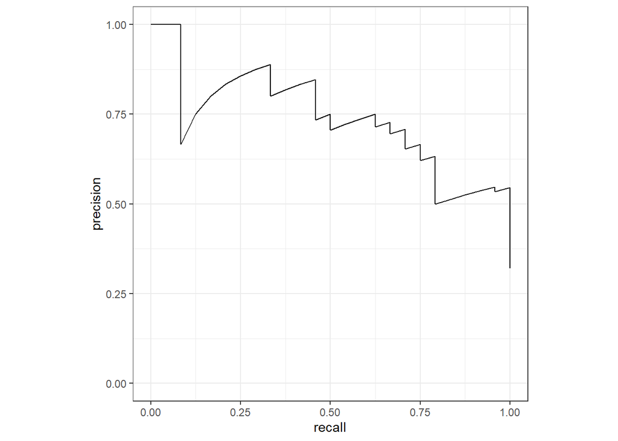

```r
preds |> pr_curve(outcome, .pred_died) |> autoplot()
```

## Reproducibility

Every result above is reproducible by construction:

- **One render, one analysis.** This report *executes* the split → tune → finalize → `last_fit` pipeline as it renders, so the printed numbers and the code that produced them are guaranteed to be the same object — they cannot drift apart, because there is no hand-made cache to fall out of date.
- **Fixed randomness.** `set.seed(123)` makes the split, the folds, and the tuning grid deterministic, so the same machine re-renders to the same numbers.
- **Pinned environment.** Package versions are locked with `renv`; `renv::snapshot()` records them in `renv.lock`, and `renv::restore()` rebuilds the exact library on another machine.
- **Stable paths.** All file access goes through `here::here()`, anchored to this step’s `.here` sentinel, so the report renders identically regardless of the working directory.
- **One outcome convention.** The event is `died` (the *first* factor level), so every metric scores `.pred_died` as the positive class by default — consistently, end to end.

That is the whole point: a clinical model someone else can re-run — and reproduce the *analysis*, number for number, not just the document. When an analysis grows too heavy to re-run on every render, the next step is not a hand-made `.rds` cache but a **pipeline** (`targets`, the Advanced capstone): it caches *with* inspectable, hash-checked intermediate targets — each one re-derivable and auditable — and compiles this very report itself.